# Embedded Inference Client API

4.1.0  
Embedded Inference Client API

- [Index]
- Introduction
- Embedded Client API
  - `AI_<NAME>_XX` C-defines
  - `ai_<name>_create()`
  - `ai_<name>_init()`
  - `ai_<name>_run()`
  - `ai_<name>_get_error()`
  - `ai_<name>_get_info()`
- Input/output xD tensor format
  - BHWC layout
  - Data format
  - Float to integer format conversion
  - Integer to float format conversion
  - Float to Qmn format conversion
  - Qmn to float format conversion
  - 1d-array tensor
  - 2d-array tensor
  - 3d-array tensor
- AI template application
- References
- Revision history

# Embedded Inference Client API

X-CUBE-AI Expansion Package

r1.1

AI PLATFORM r4.1.0 (Embedded Inference Client API 1.1.0)

Command Line Interface r1.1.0

# Introduction

This application note describes the embedded inference client API (`ai_<name>_XXX()` functions) which must be used by the C-application layer. The definition and the implementation are exported by the **X-CUBE-AI** code generator (refer to **[[2]](https://www.st.com/resource/en/user_manual/dm00570145.pdf)**, *“Generated STM32 NN library”* section) through the specialized files: `<name>.c` and `<name>.h`.

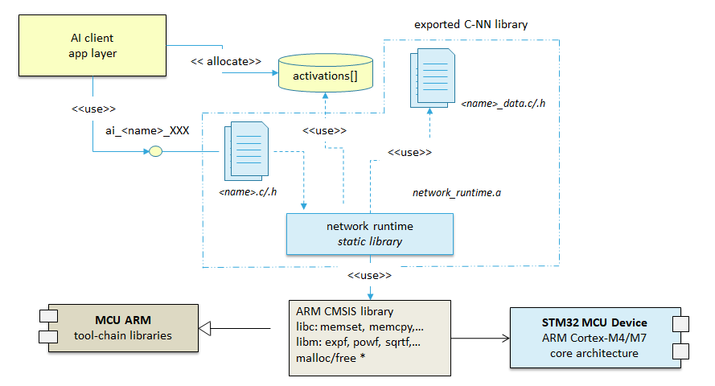

Figure 1: MCU integration model/view

**Note** — **Readers** should be aware that the proposed API is ready to support multiple input and output tensors but not yet supported by X-CUBE-AI 4.1.0 release. Code snippets (and Application AI template proposal) illustrates the nominal case with a simple input and output tensor are used.

# Embedded Client API

## `AI_<NAME>_XX` C-defines

Different C-defines are generated in the `<name>.h` and `<name>_data.h` files. They can be used to retrieve the dimensioning values for C-compile or dynamic allocation, to configure specific parameters or for debug purpose.

| C-define | description |
| --- | --- |
| `AI_<NAME>_MODEL_NAME` | C-string with the C-name of the model |
| `AI_<NAME>_IN/OUT_NUM` | indicates the total number of input/output tensors |
| `AI_<NAME>_IN/OUT` | C-table (`ai_buffer` type) to describe the input/output tensors (see `ai_<name>_run()` function) |
| `AI_<NAME>_IN/OUT_SIZE` | C-table (integer type) to indicate the number of item by input/output tensors (= H x W x C) (see *Input/output xD tensor format* section) |
| `AI_<NAME>_IN/OUT_1_SIZE` | indicates the total number of item for the first input/output tensor |
| `AI_<NAME>_IN/OUT_1_SIZE_BYTES` | indicates the size in bytes for the first input/output tensor (see `ai_<name>_run()` function) |
| `AI_<NAME>_DATA_ACTIVATIONS_SIZE` | indicates the minimal size in bytes which must provided by a client application layer as working buffer (see `ai_<name>_init()` function) |
| `AI_<NAME>_DATA__WEIGHTS_SIZE` | indicates the size in bytes of the generated weights/bias buffer chunk |

## `ai_<name>_create()`

```cpp
ai_error ai_<name>_create(ai_handle* network, const ai_buffer* network_config);
ai_handle ai_<name>_destroy(ai_handle network);
```

This **mandatory** function is the *early* function which must be called by the application to instantiate and to create an instance of the neural network. A `ai_handle` is returned and it references a run-time context (opaque object) which should be passed to the other functions.

- The `network_config` parameter is a specific network configuration buffer (opaque structure) coded as a `ai_buffer`. It is generated by the code generated and should be *not modified* by the application. The `AI_NETWORK_DATA_CONFIG` C-define should be used (see `<name>.h` file).

When the instance is no more used by the application, `ai_<name>_destroy()` function should be called to release the resources

### Typical usage

```c
#include <stdio.h>
#include "network.h"
...
/* Global handle to reference the instantiated NN */
static ai_handle network = AI_HANDLE_NULL;
...
int aiInit(void) {
    ai_error err;
    ...
    err = ai_network_create(&network, AI_NETWORK_DATA_CONFIG);
    if (err.type != AI_ERROR_NONE) {
        /* manage the error */
        printf("E: AI error - type=%d code=%d\r\n", err.type, err.code);
        ...
        }
    ...
}
```

## `ai_<name>_init()`

```cpp
ai_bool ai_<name>_init(ai_handle network, const ai_network_params* params);
```

This **mandatory** function is used by the application to initialize the internal run-time structures.

- `params` parameter is a structure (`ai_network_params` type) which allows to pass the references of the generated weights (`params` field) and the activation/crash memory buffer (`activations` field)
- `network` handle should be a valid handle, see `ai_<name>_create()` function

```c
/* @file: ai_platform.h */

typedef struct ai_network_params_ {
  ai_buffer   params;         /*! info about params buffer(required!) */
  ai_buffer   activations;    /*! info about activations buffer (required!) */
} ai_network_params;
```

- `params` attribute handles the weights/bias memory buffer
- `activations` attribute handles the activation/working memory buffer which is used by the forward process (see `ai_network_run()` function)
- size of associated memory blocks are respectively defined by the following C-defines (see `<name>_data.h` file).
  - `AI_<NAME>_DATA_WEIGHTS_SIZE`
  - `AI_<NAME>_DATA_ACTIVATIONS_SIZE`

> Memory layout of the weights/activation buffers are fully dependent of the implemented neural network.

### Typical usage

```c
#include <stdio.h>
#include "network.h"
#include "network_data.h"
...
/* Global handle to reference the instantiated NN */
static ai_handle network = AI_HANDLE_NULL;

/* Global buffer to handle the activations data buffer - R/W data */
AI_ALIGNED(4)
static ai_u8 activations[AI_NETWORK_DATA_ACTIVATIONS_SIZE];
...

int aiInit(void) {
    ai_error err;
...
   /* initialize network */
    const ai_network_params params = {
       AI_NETWORK_DATA_WEIGHTS(ai_network_data_weights_get()),
       AI_NETWORK_DATA_ACTIVATIONS(activations) };

    if (!ai_network_init(network, &params)) {
        err = ai_network_get_error(network);
        /* manage the error */
        ...
        }
...
}
```

## `ai_<name>_run()`

```cpp
ai_i32 ai_<name>_run(ai_handle network, const ai_buffer* input, ai_buffer* output);
```

This function is called to feed the neural network. The input and output buffer parameters (`ai_buffer` type) allow to provide the input tensors and to store the predicted output tensors respectively (see *Input/output xD tensor format* section and following code snippet).

- Returned value is the number of the input tensors processed when n_batches > 1. If <=0 ,`ai_network_get_error()` function should be used to know the error

**Note** — Two separate lists of inputs or/and outputs `ai_buffer` can be passed. This allows to support in the future the neural network with multiple inputs or/and outputs. `AI_NETWORK_IN_NUM` and respectively `AI_NETWORK_OUT_NUM` can be used to know at compile-time the number of inputs and outputs. These values are also returned by the `"struct ai_network_report"` (see `ai_<name>_get_info()` function).

### Typical usage

This code snippet is a typical example where only one input and one output tensor (batch size = 1) are used to perform an inference.

Note that the input and output data payload are allocated outside the *activation* working buffer.

```c
#include <stdio.h>
#include "network.h"
...
/* Global handle to reference the instantiated NN */
static ai_handle network = AI_HANDLE_NULL;

AI_ALIGNED(4)
static ai_u8 in_data[AI_NETWORK_IN_1_SIZE_BYTES];

AI_ALIGNED(4)
static ai_u8 out_data[AI_NETWORK_OUT_1_SIZE_BYTES];

...
int aiRun(const void *in_data, void *out_data)
{
    ai_i32 nbatch;
    ai_error err;
    ...
    /* 1 - Create the AI buffer IO handlers */
    ai_buffer ai_input[AI_NETWORK_IN_NUM] = AI_NETWORK_IN ;
    ai_buffer ai_output[AI_NETWORK_OUT_NUM] = AI_NETWORK_OUT ;

    /* 2 - Initialize input/output buffer handlers */
    ai_input[0].n_batches = 1;
    ai_input[0].data = AI_HANDLE_PTR(in_data);
    ai_output[0].n_batches = 1;
    ai_output[0].data = AI_HANDLE_PTR(out_data);

    /* 3 - Perform the inference */
    nbatch = ai_network_run(network, &ai_input[0], &ai_output[0]);
    if (nbatch != 1) {
        err = ai_network_get_error(network);
        // ...
        return err.code;
    }
    ...
}
```

## `ai_<name>_get_error()`

```cpp
ai_error ai_<name>_get_error(ai_handle network);
```

This function can be used by the client application to retrieve the 1st error reported during the execution of a `ai_<name>_xxx()` function. See `ai_platform.h` file to have the list of the returned error type (`ai_error_type`) and associated code (`ai_error_code`) .

### Typical AI error function handler (debug/log purpose)

```c
#include "network.h"
...
void aiLogErr(const ai_error err)
{
    printf("E: AI error - type=%d code=%d\r\n", err.type, err.code);
}
```

## `ai_<name>_get_info()`

```cpp
ai_bool ai_<name>_get_info(ai_handle network, ai_network_report* report);
```

This **optional** function can be used by the client to retrieve the attributes of the instantiated NN (debug/log purpose). Refer to `ai_platform.h` file to show the detail of the returned `ai_network_report` C-struct).

- `network` handle should be a valid handle, see `ai_<name>_create()` function

### Typical usage

```c
#include "network.h"
...
/* Global handle to reference the instantiated NN */
static ai_handle network = AI_HANDLE_NULL;
...
int aiInit(void) {
    ai_network_report report;
    ai_bool res;
...
    res = ai_network_get_info(network, &report)
    if (res) {
        /* display/use the reported data */
        ...
    }
...
}
```

# Input/output xD tensor format

Input and output tensors are **always** defined with 4 logical dimensions (BHWC format or *channel last* format representation). They are handled by a `struct ai_buffer` C-struct object. The referenced payload/data memory buffer (`data` field) is physically stored and referenced in memory as a standard C-array type. Scattered memory buffers are not supported. `format` indicate the format of the data. `meta_info` is an extra field to reference the additional data-dependent parameters which can be requested to handle a buffer.

## BHWC layout

```c
/* @file: ai_platform.h */

typedef struct ai_buffer_ {
  ai_buffer_format        format;     /*!< buffer format */
  ai_u16                  n_batches;  /*!< number of batches in the buffer */
  ai_u16                  height;     /*!< buffer height dimension */
  ai_u16                  width;      /*!< buffer width dimension */
  ai_u32                  channels;   /*!< buffer number of channels */
  ai_handle               data;       /*!< pointer to buffer data */
  ai_buffer_meta_info*    meta_info;  /*!< pointer to buffer metadata info */
} ai_buffer;
```

Following table shows the expected mapping of the 1d, 2d and 3d-array tensor:

| tensor shape | mapped on (B, H, W, C) |
| --- | --- |
| 1d-array | (-, 1, 1, c) |
| 2d-array | (-, h, 1, c) |
| 3d-array | (-, h, w, c) |

### Retrieve tensor information

Following code snippets show how to retrieve the dimensioning tensor information from a buffer descriptor (see next section for the definition of the macros)

```c
#include "network.h"

{
  /* Use the generated macro to set the buffer input descriptors */
  const ai_buffer input[] = AI_NETWORK_IN;

  /* Extract format of the first input tensor (index 0) */
  const ai_buffer_format fmt_1 = AI_BUFFER_FORMAT(&input[0])

  /* Extract height, width and channels of the first input tensor */
  const ai_u16 height_1 = AI_BUFFER_HEIGHT(&input[0])
  const ai_u16 width_1 = AI_BUFFER_WIDTH(&input[0])
  const ai_u16 ch_1 = AI_BUFFER_CHANNELS(&input[0])
  const ai_u16 size_1 = AI_BUFFER_SIZE(&input[0])
  ...
}
```

or with the `ai_network_info` structure

```c
#include "network.h"

{
  /* Fetch run-time network descriptor */
  ai_network_report report;
  ai_network_get_info(network, &report);

  /* Set the descriptor of the first input tensor (index 0) */
  const ai_buffer *input = &report.inputs[0]

  /* Extract format of the tensor */
  const ai_buffer_format fmt_1 = AI_BUFFER_FORMAT(input)

  /* Extract height, width and channels of the tensor */
  const ai_u16 height_1 = AI_BUFFER_HEIGHT(input)
  const ai_u16 width_1 = AI_BUFFER_WIDTH(input)
  const ai_u16 ch_1 = AI_BUFFER_CHANNELS(input)
  const ai_u16 size_1 = AI_BUFFER_SIZE(input)
  ...
}
```

## Data format

The format of the data is mainly defined by the field `format`, a 32b word (`ai_buffer_format` type). Two types are supported.

[output not shown]

Refer to [3], *“Supported integer format”* sub-section for detailed information.

### Helper C-macros

A well-defined set of C-macros can be used with the `format` field from a `struct ai_buffer` C-struct object to extract the information.

[output not shown]

Additional macros should be used for the meta parameters:

| macros | description |
| --- | --- |
| `AI_BUFFER_META_INFO_INTQ(meta_info)` | returns a reference on the meta information if available else `NULL` is returned. |
| `AI_BUFFER_META_INFO_INTQ_GET_SCALE()` | returns the scale value is available else `0` is returned. `ai_float` type. |
| `AI_BUFFER_META_INFO_INTQ_GET_ZEROPOINT()` | returns the zero-point value is available else `0` is returned. `ai_i8` or `ai_u8` type. Type can be deduced from the output of the `AI_BUFFER_FMT_GET_SIGN()` and `AI_BUFFER_FMT_GET_BITS()` macros. |

**Note** — User should be aware that the `meta_info` field is only available through the returned `ai_network_report` structure. Otherwise the value defined by the generated `AI_<NAME>_IN/OUT` C-define are `NULL`.

Following code snippet illustrates a typical code to extract the `m,n` values.

```c
#include "network.h"

{
  /* Use the generated macro to set the buffer input descriptors */
  const ai_buffer input[] = AI_NETWORK_IN;

  /* Extract format of the first input tensor (index 0) */
  const ai_buffer_format fmt_1 = AI_BUFFER_FORMAT(&input[0]);

  /* Extract the data type */
  const uint32_t type = AI_BUFFER_FMT_GET_TYPE(fmt_1); /* -> AI_BUFFER_FMT_TYPE_Q */

  /* Extract m,n values */
  const ai_size sign = AI_BUFFER_FMT_GET_SIGN(fmt_1);  /* -> 1 */
  const ai_size bits = AI_BUFFER_FMT_GET_BITS(fmt_1);  /* -> 8 */

  const ai_i16 N = AI_BUFFER_FMT_GET_FBITS(fmt_1);
  const ai_size M = bits - sign - N;
  ...
}
```

Extraction of the `scale, zero_point` values are showed by the following snippet code:

```c
#include "network.h"

static ai_handle network;

{
  /* Fetch run-time network descriptor. This is MANDATORY
     to retrieve the meta parameters. They are NOT available
     with the definition of the AI_<NAME>_IN/OUT macro.
  */
  ai_network_report report;
  ai_network_get_info(network, &report);

  /* Set the descriptor of the first input tensor (index 0) */
  const ai_buffer *input = &report.inputs[0]

  /* Extract format of the tensor */
  const ai_buffer_format fmt_1 = AI_BUFFER_FORMAT(input);

  /* Extract the data type */
  const uint32_t type = AI_BUFFER_FMT_GET_TYPE(fmt_1); /* -> AI_BUFFER_FMT_TYPE_Q */

  /* Extract sign and number of bits */
  const ai_size sign = AI_BUFFER_FMT_GET_SIGN(fmt_1);  /* -> 1 or 0*/
  const ai_size bits = AI_BUFFER_FMT_GET_BITS(fmt_1);  /* -> 8 */

  /* Extract scale/zero_point values (only pos=0 is currently supported, per-tensor) */
  const ai_float scale = AI_BUFFER_META_INFO_INTQ_GET_SCALE(input->meta_info, 0);
  const int zero_point = AI_BUFFER_META_INFO_INTQ_GET_ZEROPOINT(input->meta_info, 0);
  ...
}
```

Floating-point case.

```c
#include "network.h"

{
  /* Generated macro is used to set the buffer input descriptors */
  const ai_buffer input[] = AI_<NAME>_IN;

  /* Retrieve format of the first input tensor (index 0) */
  const ai_buffer_format fmt_1 = AI_BUFFER_FORMAT(&input[0]);

  /* Retrieve the data type */
  const uint32_t type = AI_BUFFER_FMT_GET_TYPE(fmt_1); /* -> AI_BUFFER_FMT_TYPE_FLOAT */

  /* Retrieve sign/size values */
  const ai_size sign = AI_BUFFER_FMT_GET_SIGN(fmt_1);   /* -> 1 */
  const ai_size bits = AI_BUFFER_FMT_GET_BITS(fmt_1);   /* -> 32 */
  const ai_size N = AI_BUFFER_FMT_GET_FBITS(fmt_1);     /* -> 0 */
  ...
}
```

## Float to integer format conversion

Following code snippet illustrates the float (ai_float) to integer (ai_i8/ai_u8) format conversion. Input buffer is used as destination buffer.

```c
#include <network.h>

#define _MIN(x_, y_) \
    ( ((x_)<(y_)) ? (x_) : (y_) )

#define _MAX(x_, y_) \
    ( ((x_)>(y_)) ? (x_) : (y_) )

#define _CLAMP(x_, min_, max_, type_) \
    (type_) (_MIN(_MAX(x_, min_), max_))

#define _ROUND(v_, type_) \
    (type_) ( ((v_)<0) ? ((v_)-0.5f) : ((v_)+0.5f) )

const ai_buffer *get_input_desc(idx) {
  ai_network_report report;
  ai_network_get_info(network, &report);
  return &report.inputs[idx];
}

ai_float input_f[AI_<NAME>_IN_1_SIZE];
ai_i8 input_q[AI_<NAME>_IN_1_SIZE]; /* or ai_u8 */

{
  const ai_buffer input = get_input_desc(0);
  ai_float scale  = AI_BUFFER_META_INFO_INTQ_GET_SCALE(input->meta_info_, 0);
  const ai_i32 zp = AI_BUFFER_META_INFO_INTQ_GET_ZEROPOINT(input->meta_info_, 0);

  scale = 1.0f / scale;

  /* Loop */
  for (int i=0; i < AI_<NAME>_IN_1_SIZE; i++)
  {
    const ai_i32 tmp_ = zp + _ROUND(input_f[i] * scale, ai_i32);
    /* for ai_u8 */
    input_q[i] = _CLAMP(tmp_, 0, 255, ai_u8);
    /* for ai_i8 */
    input_q[i] = _CLAMP(tmp_, -128, 127, ai_i8);
  }
  ...
}
```

## Integer to float format conversion

Following code snippet illustrates the integer (ai_i8/ai_u8) to float (ai_float) format conversion. The output buffer is used as source buffer.

```c
#include <network.h>

ai_i8 output_q[AI_<NAME>_OUT_1_SIZE]; /* or ai_u8 */
ai_float output_f[AI_<NAME>_OUT_1_SIZE];

const ai_buffer *get_output_desc(idx) {
  ai_network_report report;
  ai_network_get_info(network, &report);
  return &report.outputs[idx];
}

{
  const ai_buffer input = get_output_desc(0);
  ai_float scale  = AI_BUFFER_META_INFO_INTQ_GET_SCALE(input->meta_info_, 0);
  const ai_i32 zp = AI_BUFFER_META_INFO_INTQ_GET_ZEROPOINT(input->meta_info_, 0);

  /* Loop */
  for (int i=0; i<AI_<NAME>_OUT_1_SIZE; i++)
  {
    output_f[i] = scale * ((ai_float)(output_q[i]) - zp);
  }
  ...
}
```

## Float to Qmn format conversion

Following code snippet illustrates the float (ai_float) to Qmn (ai_i8) format conversion. The input tensor is used as destination buffer.

```c
#include "network.h"

#define _MIN(x_, y_) \
  ( ((x_)<(y_)) ? (x_) : (y_) )

#define _MAX(x_, y_) \
  ( ((x_)>(y_)) ? (x_) : (y_) )

#define _CLAMP(x_, min_, max_, type_) \
  (type_) (_MIN(_MAX(x_, min_), max_))

#define _ROUND(v_, type_) \
  (type_) ( ((v_)<0) ? ((v_)-0.5f) : ((v_)+0.5f) )

ai_float input_f[AI_<NAME>_IN_1_SIZE];
ai_i8 input_q[AI_<NAME>_IN_1_SIZE];

{
  const ai_buffer input[] = AI_<NAME>_IN;

  /* Retrieve format of the output tensor - index 0 */
  const ai_buffer_format fmt_ = AI_BUFFER_FORMAT(&input[0]);

  /* Build the scale factor for conversion */
  const ai_float scale = (0x1U << AI_BUFFER_FMT_GET_FBITS(fmt_));

  /* Loop */
  for (int i=0; i < AI_<NAME>_IN_1_SIZE; i++)
  {
    const ai_i32 tmp_ = _ROUND((input_f[i] * scale), ai_i32);
    input_q[i] = _CLAMP(tmp_, -128, 127, ai_i8);
  }
  ...
}
```

## Qmn to float format conversion

Following code snippet illustrates the Qmn (ai_i8) to FLOAT (ai_float) format conversion. The output tensor is used as source buffer.

```c
#include "network.h"

ai_i8 output_q[AI_<NAME>_OUT_1_SIZE];
ai_float output_f[AI_<NAME>_OUT_1_SIZE];

{
  const ai_buffer output[] = AI_<NAME>_OUT;

  /* Retrieve format of the output tensor - index 0 */
  const ai_buffer_format fmt_1 = AI_BUFFER_FORMAT(&output[0]);

  /* Build the scale factor for conversion */
  const ai_float scale = 1.0f / (0x1U << AI_BUFFER_FMT_GET_FBITS(fmt_1));

  /* Loop */
  for (int i=0; i<AI_<NAME>_OUT_1_SIZE; i++)
  {
    output_f[i] = (ai_float)(output_q[i]) * scale;
  }
  ...
}
```

## 1d-array tensor

For a `1-D tensor`, standard C-array type is expected to handle the input and output tensors.

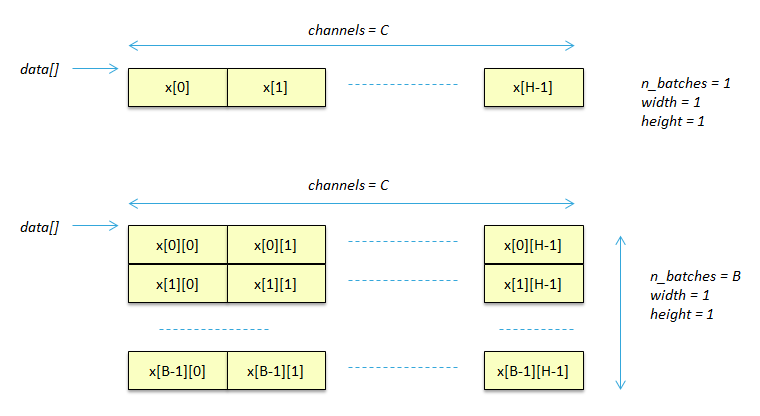

Figure 1: 1-D Tensor data layout

```c
#include "network.h"

#define xx_SIZE  VAL  /* = H * W * C = C */

ai_float xx_data[xx_SIZE];     /* n_batch = 1, height = 1, width = 1, channels = C */

ai_float xx_data[B * xx_SIZE]; /* n_batch = B, height = 1, width = 1, channels = C */
ai_float xx_data[B][xx_SIZE];
```

## 2d-array tensor

For a `2-D tensor`, standard C-array-of-array memory arrangement is used to handle the input and output tensors. 2-dim are mapped to the first two dimensions of the tensor in the original toolbox representation: e.g. H and C in Keras / Tensorflow, H and W in Lasagne.

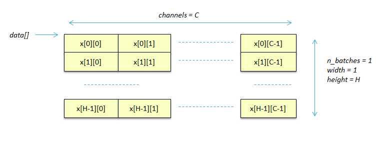

Figure 2: 2-D Tensor data layout

```c
#include "network.h"

#define xx_SIZE  VAL  /* = H * W * C = H * C */

ai_float xx_data[xx_SIZE];  /* n_batch = 1, height = H, width = 1, channels = C */
ai_float xx_data[H][C];

ai_float xx_data[B * xx_SIZE]; /* n_batch = B, height = H, width = 1, channels = C */
ai_float xx_data[B][H][C];
```

**Note** — If the dimension order in the original toolbox is different from HWC (e.g. Lasagne: CHW) it’s up to the customer to properly re-arrange the element order

## 3d-array tensor

For a `3D-tensor`, standard C-array-of-array-of-array memory arrangement is used to handle the input and output tensors.

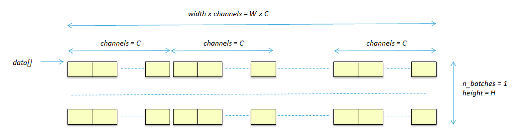

Figure 3: 3-D Tensor data layout

```c
#include "network.h"

#define xx_SIZE  VAL  /* = H * W * C */

ai_float xx_data[xx_SIZE];  /* n_batch = 1, height = H, width = W, channels = C */
ai_float xx_data[H][W][C];

ai_float xx_data[B * xx_SIZE]; /* n_batch = B, height = H, width = W, channels = C */
ai_float xx_data[B][H][W][C];
```

# AI template application

**X-CUBE-AI** [[2]](https://www.st.com/resource/en/user_manual/dm00570145.pdf) expansion package allows to generate an initial and typical ready-to-use AI template IDE project allowing the building of an AI-based application. Minimal bootstrap code is provided in the `$PRJ_DIR/Src/app_x-cube-ai.c` and `$PRJ_DIR/Inc/app_x-cube-ai.h` files. It is mostly based on the code snippets from this document.

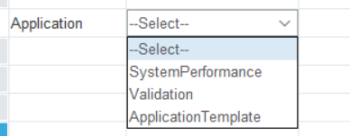

Figure 1: Application Template selection

To use the proposed `aiInit()` and `aiRun()` functions, two ways are possible:

- uses directly the proposed *X-CUBE-MX* template. The `/* USER CODE BEGIN 1 */ .. /* USER CODE END 1 */` tags to change the default code example, part of the `MX_X_CUBE_AI_Init()` and `MX_X_CUBE_AI_Process()` functions.
- calls the `aiInit()` and `aiRun()` functions from another C-file. Main file should be also modified to avoid to call the default `MX_X_CUBE_AI_Init()` and `MX_X_CUBE_AI_Process()` functions.

Application code must provide the *activations/working* memory buffer (see `MX_X_CUBE_AI_Init()` function).

```c
...
/* Global handle to reference the instance of the NN */
static ai_handle network = AI_HANDLE_NULL;
...

/*
* Init function to create and to initialize a NN.
*/
int aiInit(const ai_u8* activations)
{
   ai_error err;

   /* 1 - Specific AI data structure to handle the references of the
    * activation/working memory chunk and weights/bias parameters */
   const ai_network_params params = {
           AI_NETWORK_DATA_WEIGHTS(ai_network_data_weights_get()),
           AI_NETWORK_DATA_ACTIVATIONS(activations)
   };

   /* 2 - Create an instance of the NN */
   err = ai_network_create(&network, AI_NETWORK_DATA_CONFIG);
   if (err.type != AI_ERROR_NONE) {
       return -1;
   }

   /* 3 - Initialize the NN - Ready to be used */
   if (!ai_network_init(network, &params)) {
       err = ai_network_get_error(network);
       ai_network_destroy(network);
       network = AI_HANDLE_NULL;
       return -2;
   }

   return 0;
}
```

`aiRun()` can be used to pass an input and output data. The usage of this function is illustrated by the `MX_X_CUBE_AI_Process()` function performing a loop with the random input data.

```c
...
/* Global handle to reference the instance of the NN */
static ai_handle network = AI_HANDLE_NULL;

/* Global AI buffer IO handlers */
static ai_buffer ai_input[AI_NETWORK_IN_NUM] = AI_NETWORK_IN ;
static ai_buffer ai_output[AI_NETWORK_OUT_NUM] = AI_NETWORK_OUT ;
...

/*
 * Run function to execute an inference.
 */
int aiRun(const void *in_data, void *out_data)
{
    ai_i32 nbatch;
    ai_error err;

    /* Parameters checking */
    if (!in_data || !out_data || !network)
        return -1;

    /* 1 - Initialize input/output buffer handlers */
    ai_input[0].n_batches = 1;
    ai_input[0].data = AI_HANDLE_PTR(in_data);
    ai_output[0].n_batches = 1;
    ai_output[0].data = AI_HANDLE_PTR(out_data);

    /* 2 - Perform the inference */
    nbatch = ai_network_run(network, &ai_input[0], &ai_output[0]);
    if (nbatch != 1) {
        err = ai_network_get_error(network);
        // ...
        return err.code;
    }

    return 0;
}
```

# References

| [1] | X-CUBE-AI - *AI expansion pack for STM32CubeMX* https://www.st.com/en/embedded-software/x-cube-ai.html |
| --- | --- |
| [2] | User manual - Getting started with X-CUBE-AI Expansion Package for Artificial Intelligence (AI) [(pdf)](https://www.st.com/resource/en/user_manual/dm00570145.pdf) |
| [3] | stm32ai - Command Line Interface (link) |
| [4] | Supported Deep Learning toolboxes and layers (link) |
| [5] | Embedded inference client API (link) |
| [6] | Evaluation report and metrics (link) |
| [7] | FAQs (link) |

# Revision history

| Date | version | changes |
| --- | --- | --- |
| **2019-06-14** | r1.0 | initial version |
| **2019-09-20** | r1.1 | AI Platform 4.1.0 update. Add integer arithmetic support for quantized data. |

Online Documentation - Embedded Inference Client API  
**X-CUBE-AI Expansion Package**  
r1.1 - AI PLATFORM r4.1.0 (Embedded Inference Client API 1.1.0) - Command Line Interface r1.1.0

Information in this document is provided solely in connection with ST products. The contents of this document are subject to change without prior notice.  
© Copyright STMicroelectronics 2019. All rights reserved. www.st.com